# Analysis of White Wine Quality

### Mylu Praveen

========================================================

# Introduction:

This tidy data set contains 4,898 white wines with 11 variables on quantifying the chemical properties of each wine. At least 3 wine experts rated the quality of each wine, providing a rating between 0 (very bad) and 10 (very excellent).

# Variables contained in the Data set:

```
## 'data.frame':    4898 obs. of  13 variables:
##  $ X                   : int  1 2 3 4 5 6 7 8 9 10 ...
##  $ fixed.acidity       : num  7 6.3 8.1 7.2 7.2 8.1 6.2 7 6.3 8.1 ...
##  $ volatile.acidity    : num  0.27 0.3 0.28 0.23 0.23 0.28 0.32 0.27 0.3 0.22 ...
##  $ citric.acid         : num  0.36 0.34 0.4 0.32 0.32 0.4 0.16 0.36 0.34 0.43 ...
##  $ residual.sugar      : num  20.7 1.6 6.9 8.5 8.5 6.9 7 20.7 1.6 1.5 ...
##  $ chlorides           : num  0.045 0.049 0.05 0.058 0.058 0.05 0.045 0.045 0.049 0.044 ...
##  $ free.sulfur.dioxide : num  45 14 30 47 47 30 30 45 14 28 ...
##  $ total.sulfur.dioxide: num  170 132 97 186 186 97 136 170 132 129 ...
##  $ density             : num  1.001 0.994 0.995 0.996 0.996 ...
##  $ pH                  : num  3 3.3 3.26 3.19 3.19 3.26 3.18 3 3.3 3.22 ...
##  $ sulphates           : num  0.45 0.49 0.44 0.4 0.4 0.44 0.47 0.45 0.49 0.45 ...
##  $ alcohol             : num  8.8 9.5 10.1 9.9 9.9 10.1 9.6 8.8 9.5 11 ...
##  $ quality             : int  6 6 6 6 6 6 6 6 6 6 ...
```

# Data Munging:

We need to remove variable X as it represents serial number in the data.

```
## 'data.frame':    4898 obs. of  12 variables:
##  $ fixed.acidity       : num  7 6.3 8.1 7.2 7.2 8.1 6.2 7 6.3 8.1 ...
##  $ volatile.acidity    : num  0.27 0.3 0.28 0.23 0.23 0.28 0.32 0.27 0.3 0.22 ...
##  $ citric.acid         : num  0.36 0.34 0.4 0.32 0.32 0.4 0.16 0.36 0.34 0.43 ...
##  $ residual.sugar      : num  20.7 1.6 6.9 8.5 8.5 6.9 7 20.7 1.6 1.5 ...
##  $ chlorides           : num  0.045 0.049 0.05 0.058 0.058 0.05 0.045 0.045 0.049 0.044 ...
##  $ free.sulfur.dioxide : num  45 14 30 47 47 30 30 45 14 28 ...
##  $ total.sulfur.dioxide: num  170 132 97 186 186 97 136 170 132 129 ...
##  $ density             : num  1.001 0.994 0.995 0.996 0.996 ...
##  $ pH                  : num  3 3.3 3.26 3.19 3.19 3.26 3.18 3 3.3 3.22 ...
##  $ sulphates           : num  0.45 0.49 0.44 0.4 0.4 0.44 0.47 0.45 0.49 0.45 ...
##  $ alcohol             : num  8.8 9.5 10.1 9.9 9.9 10.1 9.6 8.8 9.5 11 ...
##  $ quality             : int  6 6 6 6 6 6 6 6 6 6 ...
```

# Description of Attributes from Data:

1. fixed acidity: most acids involved with wine or fixed or nonvolatile (do not evaporate readily).
2. volatile acidity: The amount of acetic acid in wine, which at too high of levels can lead to an unpleasant, vinegar taste.
3. citric acid: found in small quantities, citric acid can add ‘freshness’ and flavor to wines.
4. residual sugar: the amount of sugar remaining after fermentation stops, it’s rare to find wines with less than 1 gram/liter and wines with greater than 45 grams/liter are considered sweet.
5. chlorides: the amount of salt in the wine.
6. free sulfur dioxide: the free form of SO2 exists in equilibrium between molecular SO2 (as a dissolved gas) and bisulfite ion; it prevents microbial growth and the oxidation of wine.
7. total sulfur dioxide: amount of free and bound forms of S02; in low concentrations, SO2 is mostly undetectable in wine, but at free SO2 concentrations over 50 ppm, SO2 becomes evident in the nose and taste of wine.
8. density: the density of water is close to that of water depending on the percent alcohol and sugar content.
9. pH: describes how acidic or basic a wine is on a scale from 0 (very acidic) to 14 (very basic); most wines are between 3-4 on the pH scale.
10. sulphates: a wine additive which can contribute to sulfur dioxide gas (S02) levels, wich acts as an antimicrobial and antioxidant.
11. alcohol: the percent alcohol content of the wine

    Output variable (based on sensory data):
12. quality (score between 0 and 10).

# New Variables:

1. Volatile.type: represents taste where low level tends to have a good taste.
2. citric.type: represents amount of flavour in wine.
3. quality.type: represents quality on a basis of low, medium and high.
4. total.acidity: represents total amount of acidity in wine. (total.acidity = fixed.acidity + volatile.acidity)

# Adding New variables:

# Summary of Data:

```
##  fixed.acidity    volatile.acidity  citric.acid     residual.sugar
##  Min.   : 3.800   Min.   :0.0800   Min.   :0.0000   Min.   : 0.600
##  1st Qu.: 6.300   1st Qu.:0.2100   1st Qu.:0.2700   1st Qu.: 1.700
##  Median : 6.800   Median :0.2600   Median :0.3200   Median : 5.200
##  Mean   : 6.855   Mean   :0.2782   Mean   :0.3342   Mean   : 6.391
##  3rd Qu.: 7.300   3rd Qu.:0.3200   3rd Qu.:0.3900   3rd Qu.: 9.900
##  Max.   :14.200   Max.   :1.1000   Max.   :1.6600   Max.   :65.800
##
##    chlorides       free.sulfur.dioxide total.sulfur.dioxide
##  Min.   :0.00900   Min.   :  2.00      Min.   :  9.0
##  1st Qu.:0.03600   1st Qu.: 23.00      1st Qu.:108.0
##  Median :0.04300   Median : 34.00      Median :134.0
##  Mean   :0.04577   Mean   : 35.31      Mean   :138.4
##  3rd Qu.:0.05000   3rd Qu.: 46.00      3rd Qu.:167.0
##  Max.   :0.34600   Max.   :289.00      Max.   :440.0
##
##     density             pH          sulphates         alcohol
##  Min.   :0.9871   Min.   :2.720   Min.   :0.2200   Min.   : 8.00
##  1st Qu.:0.9917   1st Qu.:3.090   1st Qu.:0.4100   1st Qu.: 9.50
##  Median :0.9937   Median :3.180   Median :0.4700   Median :10.40
##  Mean   :0.9940   Mean   :3.188   Mean   :0.4898   Mean   :10.51
##  3rd Qu.:0.9961   3rd Qu.:3.280   3rd Qu.:0.5500   3rd Qu.:11.40
##  Max.   :1.0390   Max.   :3.820   Max.   :1.0800   Max.   :14.20
##
##     quality      volatile.type citric.type   total.acidity
##  Min.   :3.000   low   :4742   less  :4584   Min.   : 4.110
##  1st Qu.:5.000   middle:  90   medium: 312   1st Qu.: 6.570
##  Median :6.000   high  :  66   more  :   2   Median : 7.070
##  Mean   :5.878                               Mean   : 7.133
##  3rd Qu.:6.000                               3rd Qu.: 7.590
##  Max.   :9.000                               Max.   :14.470
##
##  quality.factor
##  3:  20
##  4: 163
##  5:1457
##  6:2198
##  7: 880
##  8: 175
##  9:   5
```

# Univariate Plots Section

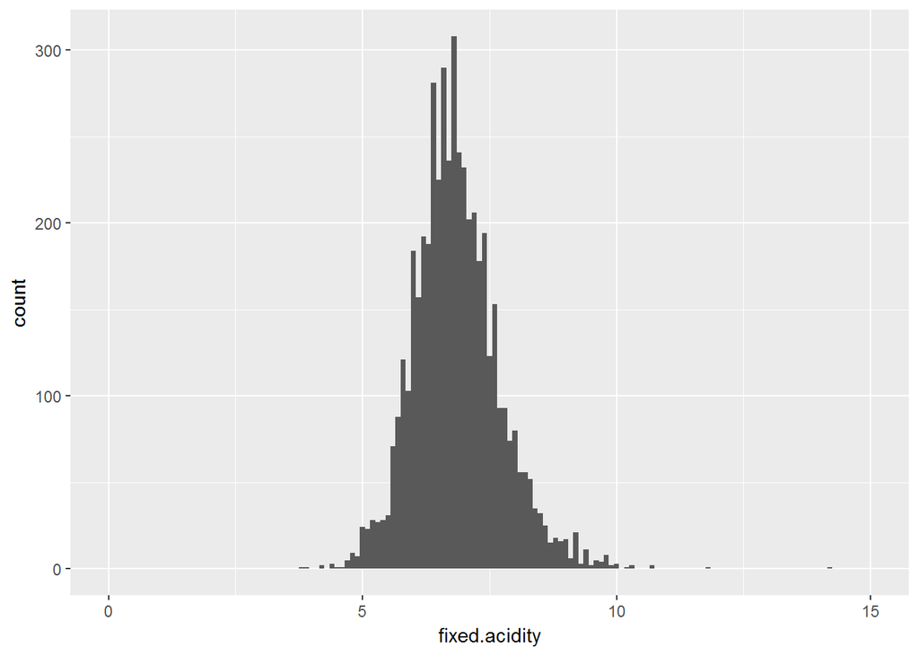

- fixed.acidity has an normal distribution with a mean of 6.855. It has a median of value 6.8 and there are very few outliers after the fixed.acidity value of 10 in this plot . The maximum count for fixed.acidity is nearly 310. fixed.acidity has an interval range of {3.80, 14.2}.

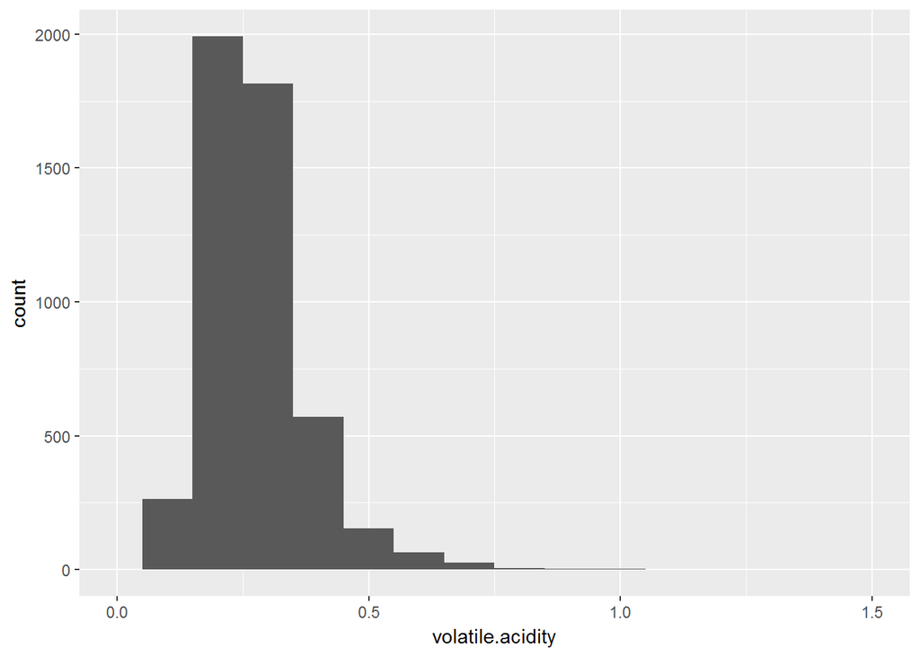

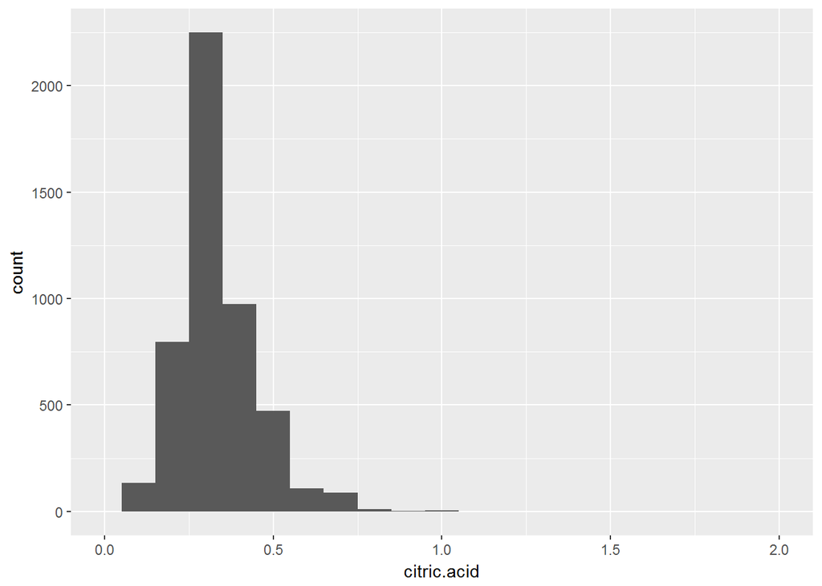

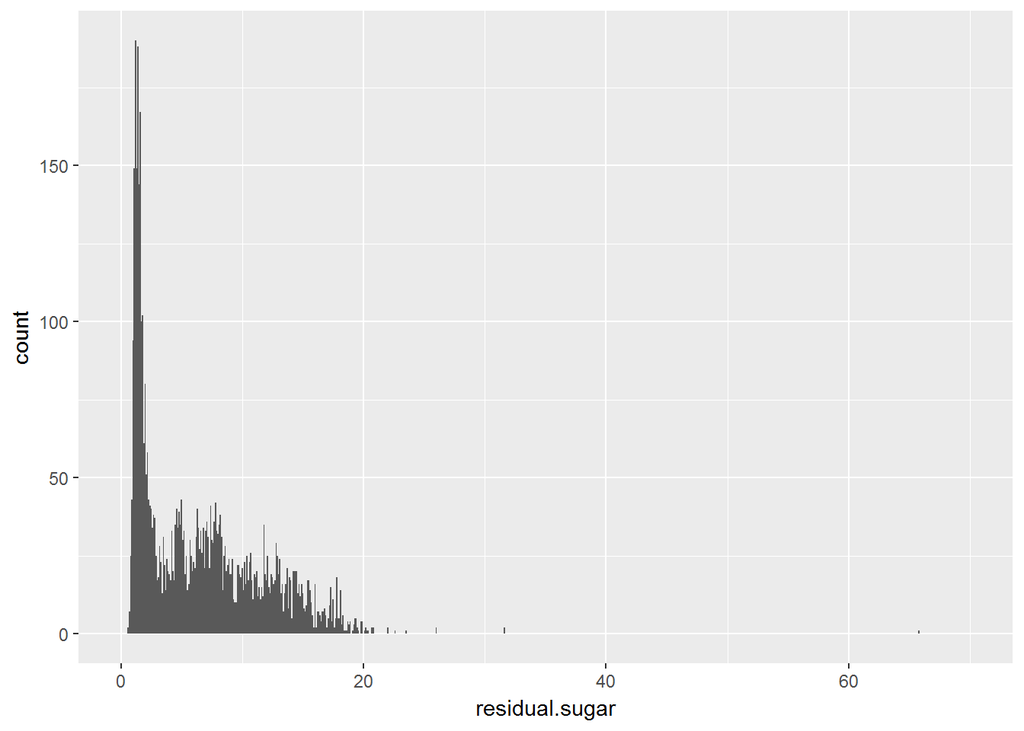

- residual.sugar is a positive skew distribution with a mean of 6.391. It has a median of a value 5.2 and there are few outliers in this plot occuring after the residual.sugar value of 20. The maximum count for residual.sugar is almost 185. residual.sugar has an interval range of {0.60, 65.8}.

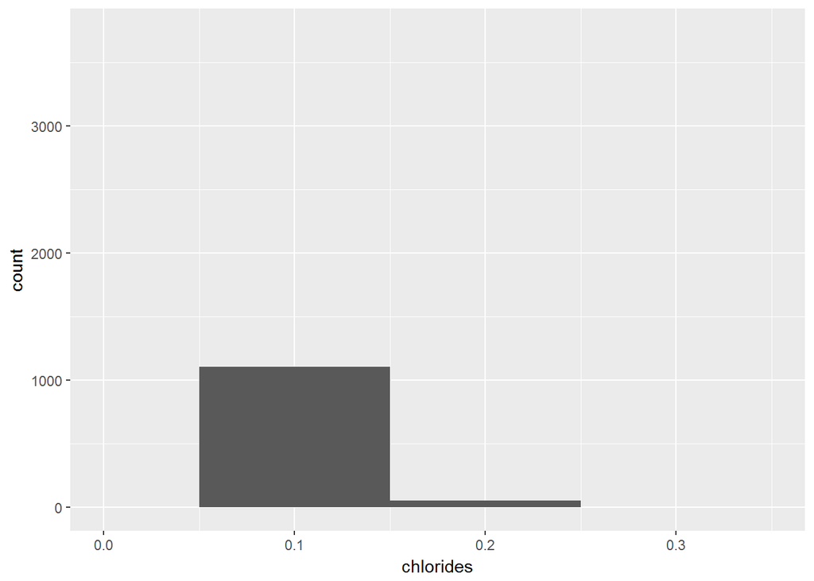

- chlorides is a positive skew distribution with a mean of 0.045. It has a median of a value 0.043 and there are no outliers in this plot. The maximum count for chlorides is almost 1100. chlorides has an interval range of {0.009, 0.346}.

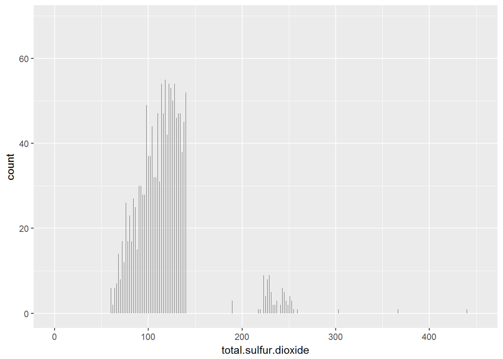

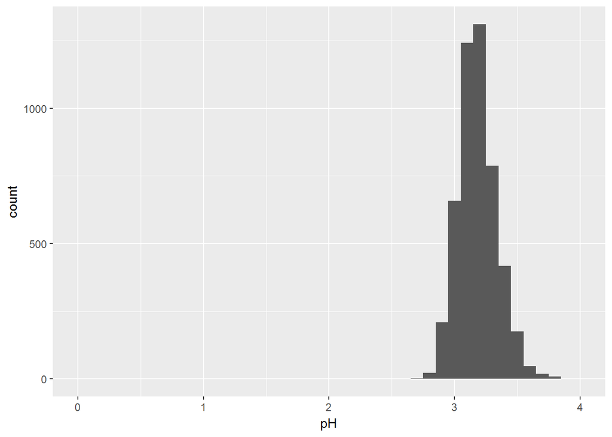

- pH is a binomial distribution with a mean of 3.188. It has a median of a value 3.18 and there are no outliers in this plot. The maximum count for pH is almost 1300. pH has an interval range of {2.72, 3.82}.

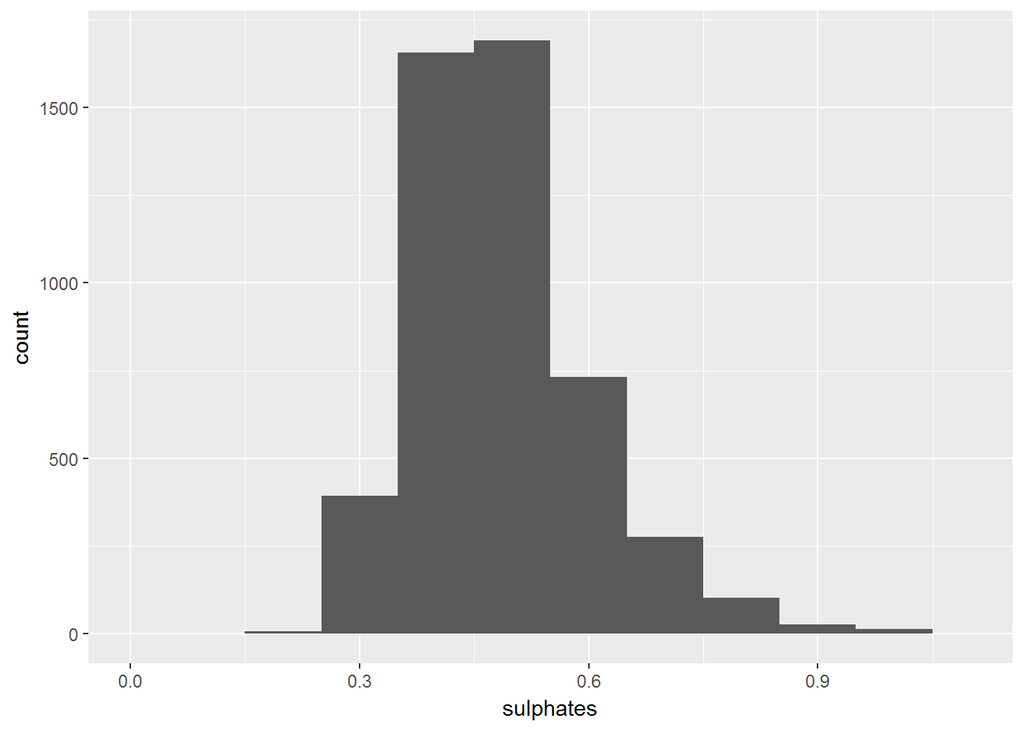

- sulphates is a binomial distribution with a mean of 0.4898. It has a median of a value 0.47 and there are no outliers in this plot. The maximum count for sulphates is almost 1700. sulphates has an interval range of {0.22, 1.08}.

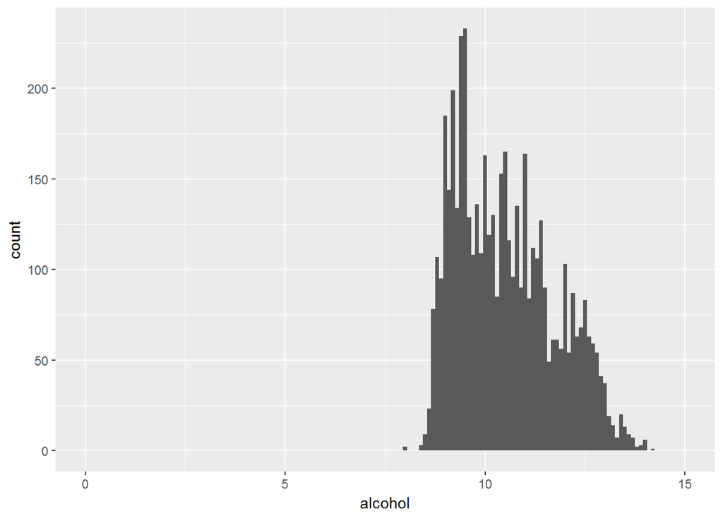

- alcohol is a positive skew distribution with a mean of 10.51. It has a median of a value 10.4 and there is an single outlier near to 14 in this plot. The maximum count for alcohol is almost 235. alcohol has an interval range of {8, 14.2}.

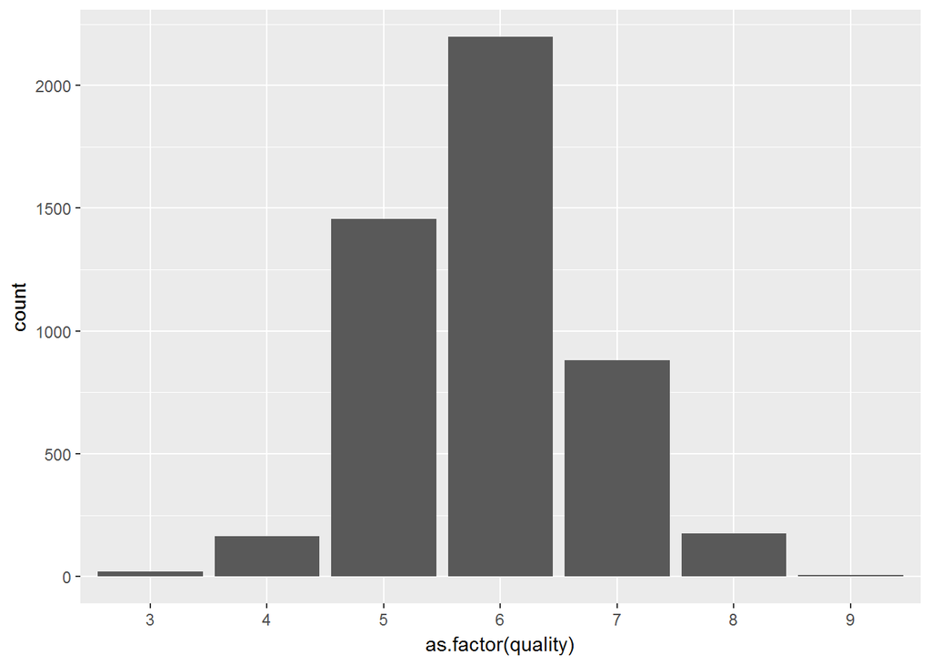

# New variables Plots Section

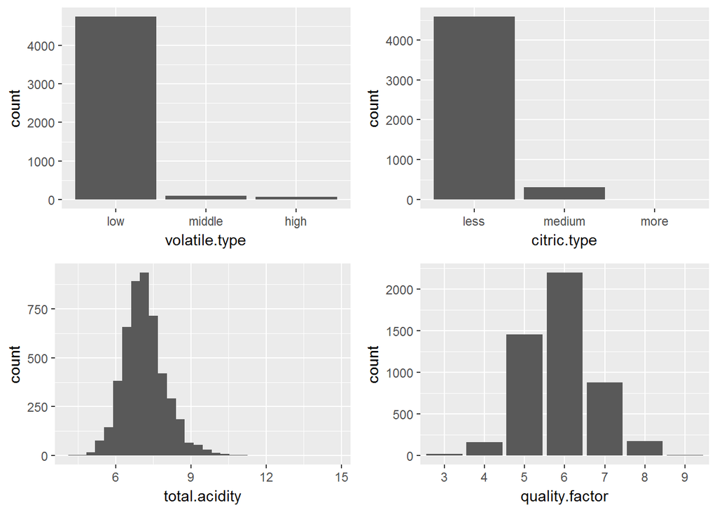

- White wine produces more amount of low volatile.type which says it consists of more amount of good taste. low volatile.type has a count of 4742, middle volatile.type of 90 and high volatile.type of 66.
- White wine consists of less amount of flavour in wine. less citric.type has a count of 4584, medium citric.type of 312 and more citric.type of 2.
- White wine produces a better quality wine. normal quality.type has a count of 20, better quality.type of 3818 and good quality.type of 1060.
- total amount of acidity is an binomial distribution with a mean of 7.133. It has a median of a value 7.07 and there are no outliers in this plot. The maximum count for total.acidity is almost 900. total.acidity has an interval range of {4.11, 14.47}.

# Transforming Variables

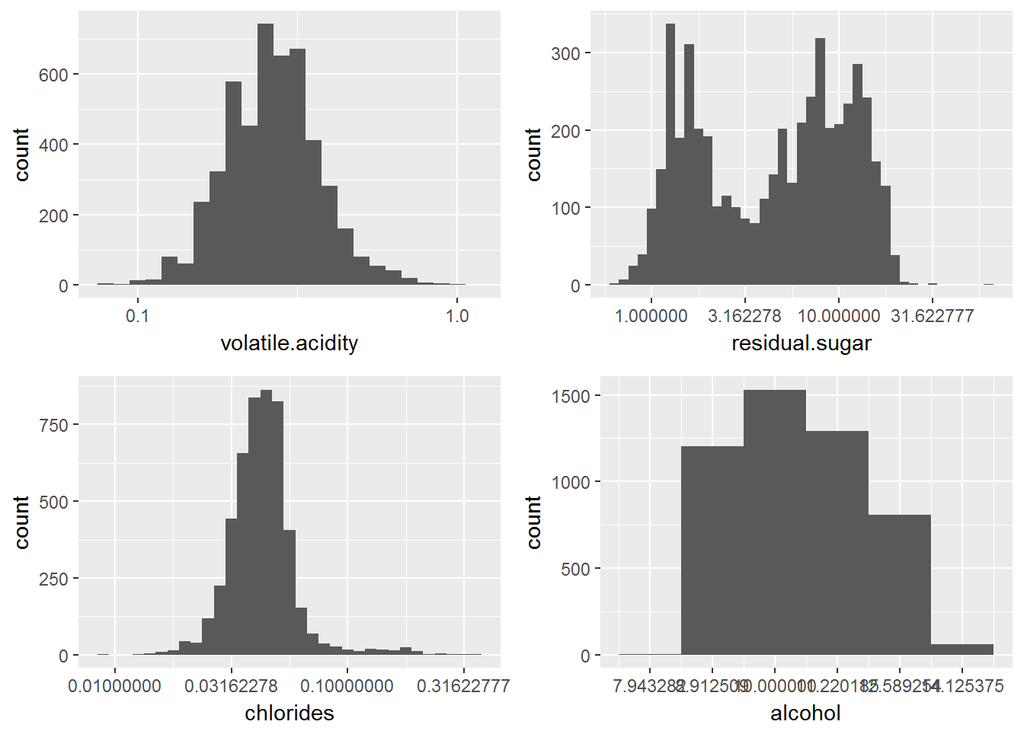

we have used breaks parameter, so that we can observe sufficient tickmarks in every plot and find the values that are reflected in a particular position in the log scaled axis.

# Correlation between variables

1. quality vs alcohol

```
##
##  Pearson's product-moment correlation
##
## data:  wine$quality and wine$alcohol
## t = 33.858, df = 4896, p-value < 2.2e-16
## alternative hypothesis: true correlation is not equal to 0
## 95 percent confidence interval:
##  0.4126015 0.4579941
## sample estimates:
##       cor
## 0.4355747
```

- The correlation between quality and alcohol is 0.4355747.
2. alcohol vs density

```
##
##  Pearson's product-moment correlation
##
## data:  wine$alcohol and wine$density
## t = -87.255, df = 4896, p-value < 2.2e-16
## alternative hypothesis: true correlation is not equal to 0
## 95 percent confidence interval:
##  -0.7908646 -0.7689315
## sample estimates:
##        cor
## -0.7801376
```

- The correlation between alcohol and density is -0.7801376.
3. chlorides vs sulphates

```
##
##  Pearson's product-moment correlation
##
## data:  wine$chlorides and wine$sulphates
## t = 1.1731, df = 4896, p-value = 0.2408
## alternative hypothesis: true correlation is not equal to 0
## 95 percent confidence interval:
##  -0.01124885  0.04474833
## sample estimates:
##        cor
## 0.01676288
```

- The correlation between chlorides and sulphates is 0.01676288.
4. chlorides vs density

```
##
##  Pearson's product-moment correlation
##
## data:  wine$chlorides and wine$density
## t = 18.624, df = 4896, p-value < 2.2e-16
## alternative hypothesis: true correlation is not equal to 0
## 95 percent confidence interval:
##  0.2308679 0.2831779
## sample estimates:
##       cor
## 0.2572113
```

- The correlation between chlorides and density is 0.2572113 .
5. alcohol vs density

```
##
##  Pearson's product-moment correlation
##
## data:  wine$alcohol and wine$density
## t = -87.255, df = 4896, p-value < 2.2e-16
## alternative hypothesis: true correlation is not equal to 0
## 95 percent confidence interval:
##  -0.7908646 -0.7689315
## sample estimates:
##        cor
## -0.7801376
```

- The correlation between alcohol and density is -0.7801376.

# Bivariate Plots Section

### Volatile.acidity vs citric.acid

```
##
##  Pearson's product-moment correlation
##
## data:  wine$volatile.acidity and wine$citric.acid
## t = -10.578, df = 4896, p-value < 2.2e-16
## alternative hypothesis: true correlation is not equal to 0
## 95 percent confidence interval:
##  -0.1767384 -0.1219760
## sample estimates:
##        cor
## -0.1494718
```

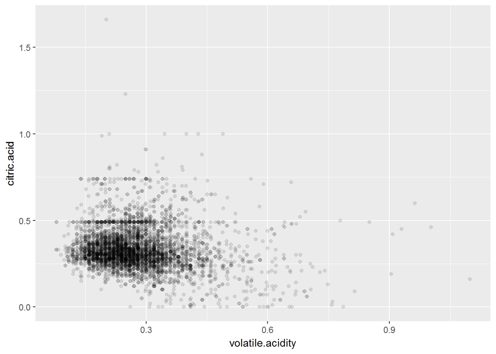

- From volatile.acidity vs citric.acid plot, we observe a negative correlation between them. The data lies mostly between the 2nd and 3rd quartile. volatile.acidity depends on the taste of the wine where less amount of volatile gives the better taste and citric.acid depends on the addition of flavour and freshness to wine where higher the amount of citric acid increases the freshness and flavour to the wine. Therefore I conclude that the wines that we can prefer containing a volatile.acidity of nearly 0.18 which would be of much taste, also containing the citric.acid of 1.7. some amount of outliers also exists in this plot.

### free.sulfur.dioxide vs total.sulfur.dioxide

```
##
##  Pearson's product-moment correlation
##
## data:  wine$free.sulfur.dioxide and wine$total.sulfur.dioxide
## t = 54.645, df = 4896, p-value < 2.2e-16
## alternative hypothesis: true correlation is not equal to 0
## 95 percent confidence interval:
##  0.5977994 0.6326026
## sample estimates:
##      cor
## 0.615501
```

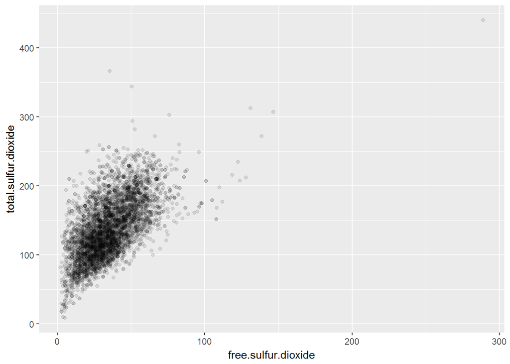

- From free.sulfur.dioxide vs total.sulfur.dioxide plot, we observe a positive correlation between them. The data mostly lies in the interquartile range i.e. between 1st and 3rd quantile.

# Multivariate Plots Section

### density vs pH colored by quality.factor

```
##
##  Pearson's product-moment correlation
##
## data:  wine$density and wine$pH
## t = -6.5776, df = 4896, p-value = 5.281e-11
## alternative hypothesis: true correlation is not equal to 0
## 95 percent confidence interval:
##  -0.1212801 -0.0657574
## sample estimates:
##         cor
## -0.09359149
```

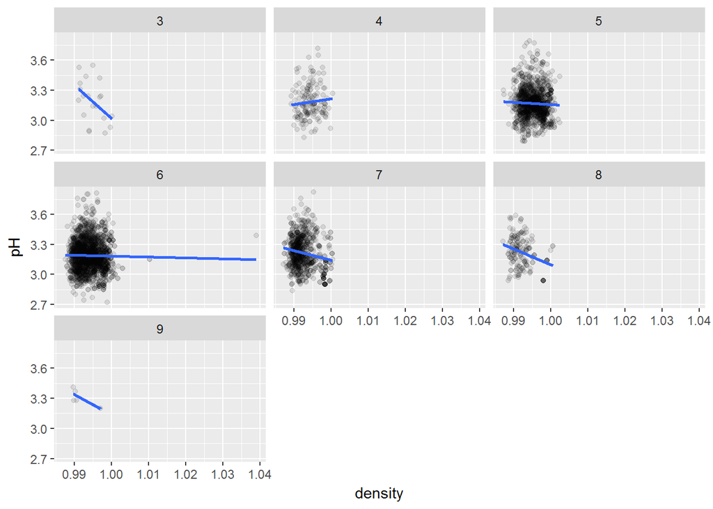

- From this density vs pH plot, we used facet for quality.factor and also found negative correlation between density and pH. Later on we used geom_smooth to add a summary line in the plot.

### alcohol vs sulphates facet by quality

```
##
##  Pearson's product-moment correlation
##
## data:  wine$alcohol and wine$sulphates
## t = -1.22, df = 4896, p-value = 0.2225
## alternative hypothesis: true correlation is not equal to 0
## 95 percent confidence interval:
##  -0.04541705  0.01057885
## sample estimates:
##         cor
## -0.01743277
```

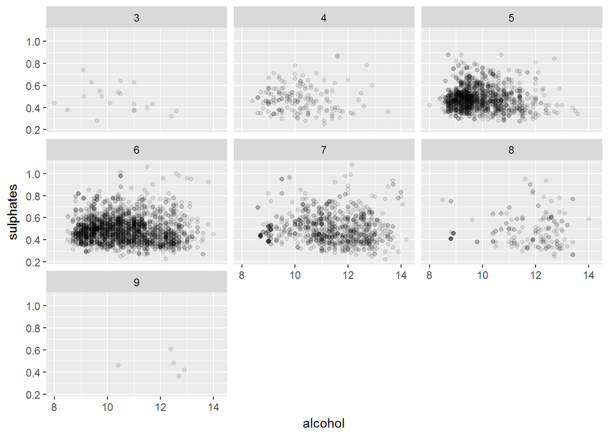

# Final Plots and Summary

### Plot One

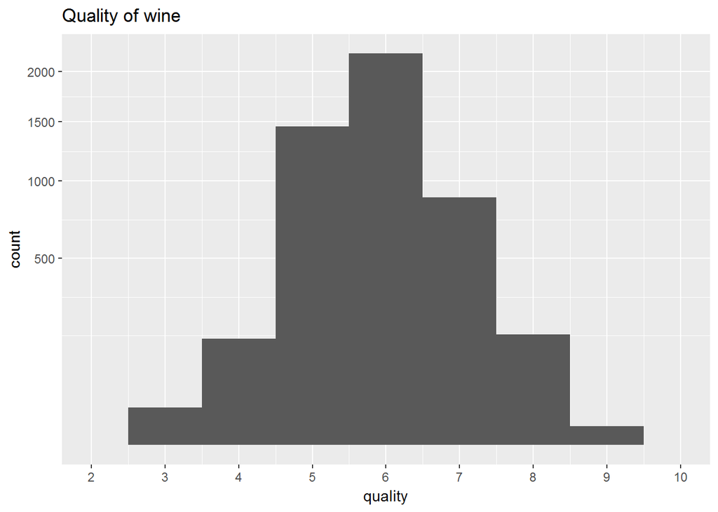

### Plot Two

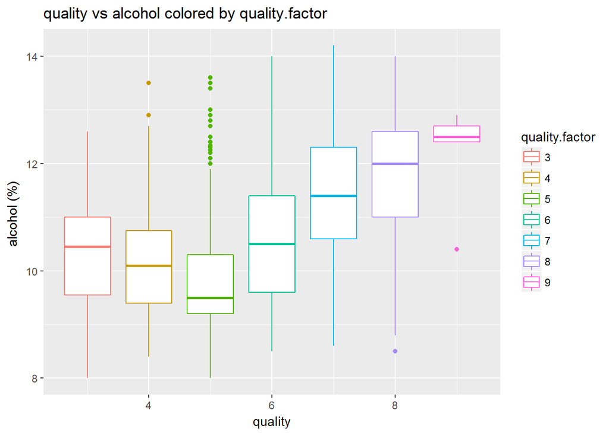

### plot Three

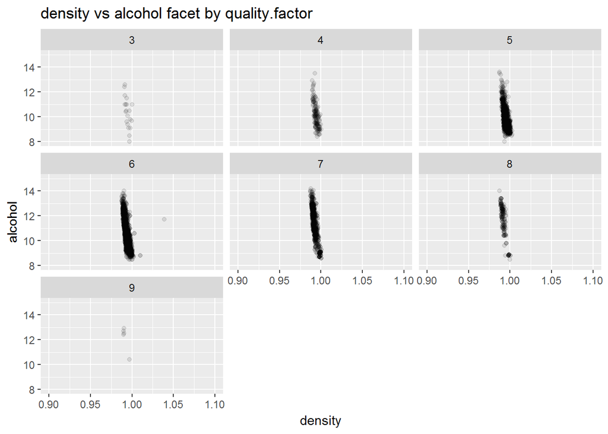

### Description Three

From the above plot, we observe that quality 7 has the highest alcohol percentage and quality 5 has the lowest alcohol percentage. we have a correlation of -0.78 between density and alcohol. The reason i choosed this plot is to find the alcohol percentage based on the quality. I have used facet_wrap command to analyze density vs alcohol in each quality and also adjusted axis limit inorder to reduce overplotting.

# Reflection

From the given white wine quality data set i have analyzed some the data with the help of some major variables. I have plotted necessary correlated plots of various variables.

The intresting feature in analyzing is by finding the final plots with each plot with different type of plot such as boxplot and scatterplot. I have found and anlayzed different types of plot in univariate, Bivariate and Multivariate plots.

There is no much difficulty in analyzing the plots where it would be even more better if more properties of wine are included in the data set.

My future exploration from this data will be adding some other additional properties such as age of the wine, type of the wine etc. It would help us to analyze more information and create better models.